# HW 5

Data 180, Professor Kennedy

Tommy Eaton

eatont@dickinson.edu

November 07, 2023

**Due date:** November 2 beginning of class.

# Question 1

```r
X <- matrix(c(-1,-2,4,2,0,0,-2,2,2,-1,-1,3,3,0,0,2,2,-3,1,1),nrow=5,byrow = T)
print(X)
```

```
##      [,1] [,2] [,3] [,4]
## [1,]   -1   -2    4    2
## [2,]    0    0   -2    2
## [3,]    2   -1   -1    3
## [4,]    3    0    0    2
## [5,]    2   -3    1    1
```

```r
library(MASS)
library(dplyr)
Vans93 <- filter(Cars93, Type == "Van") %>%
  dplyr::select(Model, Price, EngineSize, Horsepower, MPG.highway, Length)
nrow(Vans93)
```

```
## [1] 9
```

```r
print(Vans93)
```

```
##        Model Price EngineSize Horsepower MPG.highway Length
## 1 Lumina_APV  16.3        3.8        170          23    178
## 2      Astro  16.6        4.3        165          20    194
## 3    Caravan  19.0        3.0        142          21    175
## 4   Aerostar  19.9        3.0        145          20    176
## 5        MPV  19.1        3.0        155          24    190
## 6      Quest  19.1        3.0        151          23    190
## 7 Silhouette  19.5        3.8        170          23    194
## 8     Previa  22.7        2.4        138          22    187
## 9    Eurovan  19.7        2.5        109          21    187
```

2. Use the `dist` and `as.matrix` functions to find the distance matrix for the vans set using the Euclidean metric. Call this matrix `Vans_Euclidean`. You will need to remove the first column of the `Vans93` dataframe when you pass it into the `dist` function, since the variable `Model` is not an appropriate variable for the cluster variate. You can do this by passing in `Vans93[,-1]` or `Vans93[,2:6]` (or any other way you like), converting it to a matrix and storing it as `Vans_Euclidean`. Next, set the row and column names of `Vans_Euclidean` to the Models of the vans using the rownames and colnames functions, so that it is easier for us to see what object we have in each row/column. Hint: This can be done by typing

```
colnames(Vans_Euclidean)<-Vans93[,1]
rownames(Vans_Euclidean)<-Vans93[,1]
```

Finally, round the values in this matrix to the hundredths place (two decimal points). Paste the final version of the matrix `Vans_Euclidean` into your solutions. Which two Vans (give the models) have the shortest distance between them? Which two have the largest distance between them?

```r
Vans_Euclidean <- as.matrix(dist(as.matrix(Vans93[, -1]), method = "euclidean"))

colnames(Vans_Euclidean) <- rownames(Vans_Euclidean) <- Vans93$Model

Vans_Euclidean <- round(Vans_Euclidean, digits = 2)

min_distance <- min(Vans_Euclidean[Vans_Euclidean > 0])
max_distance <- max(Vans_Euclidean)

shortest_distance_vans <- which(Vans_Euclidean == min_distance, arr.ind = TRUE)
largest_distance_vans <- which(Vans_Euclidean == max_distance, arr.ind = TRUE)

shortest_distance_models <- rownames(Vans_Euclidean)[shortest_distance_vans]
largest_distance_models <- rownames(Vans_Euclidean)[largest_distance_vans]

cat("Vans with the shortest distance: ", shortest_distance_models[1], " and ", shortest_distance_models[2], "\n")
```

```
## Vans with the shortest distance:  Aerostar  and  Caravan
```

```r
cat("Vans with the largest distance: ", largest_distance_models[1], " and ", largest_distance_models[2], "\n")
```

```
## Vans with the largest distance:  Eurovan  and  Lumina_APV
```

```r
print(Vans_Euclidean)
```

```
##            Lumina_APV Astro Caravan Aerostar   MPV Quest Silhouette Previa
## Lumina_APV       0.00 17.04   28.37    25.53 19.45 22.66      16.32  33.90
## Astro           17.04  0.00   29.97    27.14 11.83 15.13       6.53  28.68
## Caravan         28.37 29.97    0.00     3.44 20.08 17.61      33.91  13.23
## Aerostar        25.53 27.14    3.44     0.00 17.68 15.54      30.96  13.50
## MPV             19.45 11.83   20.08    17.68  0.00  4.12      15.58  17.76
## Quest           22.66 15.13   17.61    15.54  4.12  0.00      19.44  13.87
## Silhouette      16.32  6.53   33.91    30.96 15.58 19.44       0.00  32.96
## Previa          33.90 28.68   13.23    13.50 17.76 13.87      32.96   0.00
## Eurovan         61.80 56.56   35.12    37.66 46.20 42.16      61.45  29.17
##            Eurovan
## Lumina_APV   61.80
## Astro        56.56
## Caravan      35.12
## Aerostar     37.66
## MPV          46.20
## Quest        42.16
## Silhouette   61.45
## Previa       29.17
## Eurovan       0.00
```

3. Repeat the steps in part (b) but use the Manhattan metric and call the object `Vans_Manhattan`.

```r
Vans_Manhattan <- as.matrix(dist(as.matrix(Vans93[, -1]), method = "manhattan"))

colnames(Vans_Manhattan) <- rownames(Vans_Manhattan) <- Vans93$Model

Vans_Manhattan <- round(Vans_Manhattan, digits = 2)

print(Vans_Manhattan)
```

```
##            Lumina_APV Astro Caravan Aerostar  MPV Quest Silhouette Previa
## Lumina_APV        0.0  24.8    36.5     34.4 31.6  34.6       19.2   49.8
## Astro            24.8   0.0    46.7     42.6 21.8  24.8       11.4   44.0
## Caravan          36.5  46.7     0.0      5.9 31.1  26.1       50.3   21.3
## Aerostar         34.4  42.6     5.9      0.0 28.8  23.8       47.2   23.4
## MPV              31.6  21.8    31.1     28.8  0.0   5.0       21.2   26.2
## Quest            34.6  24.8    26.1     23.8  5.0   0.0       24.2   21.2
## Silhouette       19.2  11.4    50.3     47.2 21.2  24.2        0.0   44.6
## Previa           49.8  44.0    21.3     23.4 26.2  21.2       44.6    0.0
## Eurovan          76.7  68.9    46.2     48.7 53.1  48.1       71.5   33.1
##            Eurovan
## Lumina_APV    76.7
## Astro         68.9
## Caravan       46.2
## Aerostar      48.7
## MPV           53.1
## Quest         48.1
## Silhouette    71.5
## Previa        33.1
## Eurovan        0.0
```

The vans with the shortest distance between them are the Quest and the MPV (5.0). The vans with the largest distance between them are the Lumina APV and the Eurovan (76.7).

# Question 3

Suppose you are given the following 6 x 6 *distance matrix*:

```r
D <- matrix(c(0,1,9,2,1.6,8,1,0,3,6,9,4,9,3,0,5,10,3,2,6,5,0,2,7.5,1.6,9,10,2,0,5.5,8,4,3,7.5,5.5,0),nrow=6,byrow = T)
print(D)
```

```
##      [,1] [,2] [,3] [,4] [,5] [,6]
## [1,]  0.0    1    9  2.0  1.6  8.0
## [2,]  1.0    0    3  6.0  9.0  4.0
## [3,]  9.0    3    0  5.0 10.0  3.0
## [4,]  2.0    6    5  0.0  2.0  7.5
## [5,]  1.6    9   10  2.0  0.0  5.5
## [6,]  8.0    4    3  7.5  5.5  0.0
```

Find (by hand) the inter-group distance between A = $\{O_1, O_4\}$ and B = $\{O_2, O_3, O_5\}$ (where $O_n$ denotes the $n$th object in the distance matrix **D**) using

1. Nearest-neighbor d = 1
2. Farthest-neighbor

[figure not shown]

Caption: 11 frequently used English words

Using this dendrogram, break these 11 words into five clusters. Call them $C_1 – C_5$ and put their members inside curly brackets, e.g. $C_2 = \{with, for\}$. Comment on your grouping using 1-2 sentences.

# Question 5

Let’s practice hierarchical clustering with the `vertebrate` dataset that is saved in the hw folder on GitHub. Animals are divided into two categories [vertebrates and invertebrates](https://www.oum.ox.ac.uk/thezone/animals/animalid/divide.htm#:~:text=Invertebrates%20-%20animals%20without%20a%20backbone,a%20vertebrate%20or%20an%20invertebrate.). Vertebrates are also divided within themselves into groups such as mammals, birds, reptiles.. Our task in this question is to identify groups within vertebrates that share similar traits.

1. First, read in the `vertebrate.csv` file and store it in a dataframe object named `vertebrate`. How many rows does the dataframe have? Print the entire dataset in your solutions.

```r
library(readr)
vertebrate<- read_csv("vertebrate.csv")
num_rows <- nrow(vertebrate)
print(vertebrate)
```

```
## # A tibble: 15 × 8
##    Name        `Warm-blooded` `Gives Birth` `Aquatic Creature` `Aerial Creature`
##    <chr>                <dbl>         <dbl>              <dbl>             <dbl>
##  1 human                    1             1                  0                 0
##  2 python                   0             0                  0                 0
##  3 salmon                   0             0                  1                 0
##  4 whale                    1             1                  1                 0
##  5 frog                     0             0                  1                 0
##  6 komodo                   0             0                  0                 0
##  7 bat                      1             1                  0                 1
##  8 pigeon                   1             0                  0                 1
##  9 cat                      1             1                  0                 0
## 10 leopard sh…              0             1                  1                 0
## 11 turtle                   0             0                  1                 0
## 12 penguin                  1             0                  1                 0
## 13 porcupine                1             1                  0                 0
## 14 eel                      0             0                  1                 0
## 15 salamander               0             0                  1                 0
## # ℹ 3 more variables: `Has Legs` <dbl>, Hibernates <dbl>, Class <chr>
```

```r
cat("Number of rows in the dataframe: ", num_rows, "\n")
```

```
## Number of rows in the dataframe:  15
```

2. Perform two separate clustering analyses of the data using the `hclust` function. Provide the dendrograms for both clustering methods.
1. using the Euclidean metric with complete linkage. Note: Similar to Question 2, start by creating a distance matrix named `vertebrate_euclidean` which should not include any text column. Add row and column names to the matrix from the `vertebrate` dataframe. Then apply `dist()` once again before feeding the matrix into `hclust()` function.

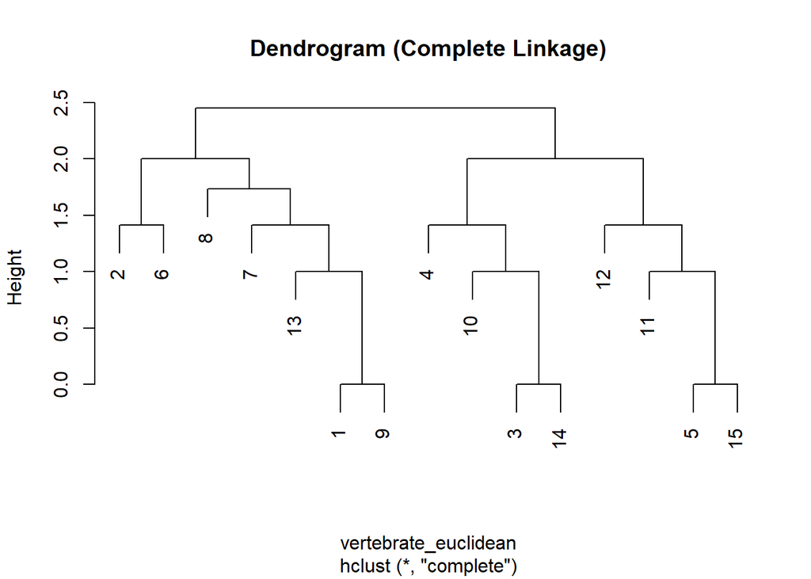

```r
vertebrate_numeric <- vertebrate[, sapply(vertebrate, is.numeric)]

vertebrate_euclidean <- dist(vertebrate_numeric, method = "euclidean")

hclust_complete <- hclust(vertebrate_euclidean, method = "complete")

plot(hclust_complete, main = "Dendrogram (Complete Linkage)")
```

(ii)using the Manhattan metric with single linkage and

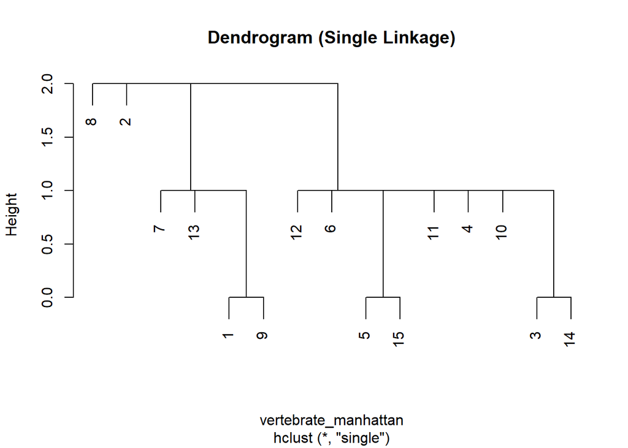

```r
vertebrate_numeric <- vertebrate[, sapply(vertebrate, is.numeric)]

vertebrate_manhattan <- dist(vertebrate_numeric, method = "manhattan")

hclust_single <- hclust(vertebrate_manhattan, method = "single")

plot(hclust_single, main = "Dendrogram (Single Linkage)")
```

Which method do you prefer?

manhattan In your dendrograms:

- Set the line width to 3 using `lwd=3`
- Set the title to “Clustered vertebrates, Metric type,Linkage type” (You should enter the metric and linkage used in the clustering.)
- Remove the subtitle by setting `sub=""`.
- Set the x-axis label to Vertebrates using `xlab="Vertebrates"` with `cex.lab=1.25`
- Have the terminal edges extend to a height of zero by setting `hang=-1` such that labels appear on the same vertical height.

Bonus: (not required) generate the same dendrogram using the `ggdendro` package.

You are done! 🏁 Don’t forget to commit and push your .Rmd file to your Github repository before the due date.